# normCCS 目标函数：兼容性、搜索质量与运行成本

Bensz Conan

2026-10-29

## 改造带来了什么

CCS 的目标函数现在可以通过 `norm_objective` 选择。旧脚本继续使用包含 `All` 的 AUC 中位数；需要比较队列平均效果或较差队列表现时，可以显式切换目标。穷举、DP 初值筛选、单切点和双切点精修、最终 ROC 复核都采用同一个评分定义。

研究者现在可以在同一份数据上比较不同的分级标准，并明确记录选择依据。评分模块没有新增依赖，也没有改变 RR/NRR 排序、自动 ROC 方向或 `OptimizeRank` 的统计定义。负责人指定的软件版本为 **0.8.6**。默认结果回归、公开接口和包检查的执行记录见 验证说明。

本次完成了 600 个小规模质量比较和 100 次较大规模搜索。相同目标下，DP 与完整穷举的最大差距为 0.027469，6 个问题超过工程比较尺度。下文保留全部问题，避免用平均值掩盖未达到最优的情况。

## 五种目标如何选择

| 目标 | 纳入队列与计算方式 | 适合回答的问题 |
| --- | --- | --- |
| `median` | `All` 与真实队列 AUC 的中位数；沿用 `na.rm = TRUE` | 如何完整复现旧分析？ |
| `cohort_median` | 真实队列 AUC 中位数 | 排除 pooled `All` 后，中位数择优是否变化？ |
| `mean` | 真实队列 AUC 等权平均 | 哪个分级的平均队列表现最好？ |
| `lower_tail` | 最低 25% 队列概率质量的均值 | 哪个分级更照顾较差队列？ |
| `mean_lower_tail` | 均值与下尾均值各占 0.5 | 如何兼顾平均表现与较差队列？ |

`All` 来自合并样本，其 AUC 包含跨队列病例—对照比较，并不是独立队列。四种新目标均排除它，但仍在 `Raw` 中保留该行以便核对。队列等权也不等于样本等权或癌种等权。下尾比例与混合权重固定，便于比较，尚未经过最优超参数验证。

下尾均值使用分数权重。例如，五个真实队列的 AUC 从低到高为 a₁ 至 a₅，则得分是 `(a₁ + 0.25 × a₂) / 1.25`；只有一个真实队列时，四种新策略都返回该队列 AUC。新增策略要求所有真实队列 AUC 有限，不通过丢弃缺失队列提高分数。

```r
fit <- CCS::subtypePerformance(
  df, col_subtype = "Subtype", col_tissue = "tumor_type",
  n_norm_subtype = 8, norm_search_method = "dp",
  norm_roc_method = "Raw", norm_rank_marker = "NRR",
  norm_objective = "mean_lower_tail", numCores = 1
)
fit$Data$Normalization$Summary[1, ]
fit$Repeat$norm_objective
```

`norm_objective` 追加在形参末尾，旧的位置参数含义保持不变。新策略的最佳候选位于 `Summary` 首行，按 `objectiveScore`、真实队列均值降序，再按 `Info` 升序排列。`medianROCAUC` 始终保留旧定义，可能不随行序下降。缺少 `Repeat$norm_objective` 表示遗留 `median`，包括显式选择 `median` 的调用。

## 不同目标实际选出了什么

本报告的特定指标按以下口径解释；公式对应 `R/subtype_norm_objective.R`，搜索差距与耗时由 `benchmark-objectives.R` 计算。

同一合成问题：种子 1，M=10，C=5，K=4，Raw ROC

| 指标 | 问题与尺度 | 参考点与方向 | 不确定性和判读边界 |
| --- | --- | --- | --- |
| `objectiveScore` | 按选定规则汇总队列 AUC，范围 0–1 | 同一目标、同一数据上越高越好 | 固定数据的描述值；无总体区间，不跨目标比较大小 |
| 下尾均值 | 最差 25% 队列概率质量的 AUC，范围 0–1 | 越高表示较差队列得分更高 | 可能受小队列噪声影响，不代表临床获益 |
| `gap` | 同一目标的穷举最优值减 DP 最优值 | 零表示本例匹配，越低越好 | 固定种子逐例保留，无总体区间；不保证未知输入 |
| 新／旧 DP 耗时比 | 目标抽象后运行成本相对旧版的比例 | 一表示相同，小于一表示本次更快 | 多次计时的描述性比较，无总体区间 |
| 穷举／DP 加速比 | 两种搜索实际耗时之比 | 一表示相同，大于一表示 DP 更快 | 包含穷举 worker 成本，不能外推到未测规模 |

|  | 目标 | 目标得分 | 队列均值 | 队列中位数 | 队列下尾 | 切点 | 等级人数 |
| --- | --- | --- | --- | --- | --- | --- | --- |
| 301 | median | 0.769600 | 0.751852 | 0.803782 | 0.584927 | 2,6,9 | 52,205,233,124 |
| 302 | cohort_median | 0.805271 | 0.738759 | 0.805271 | 0.549645 | 2,6,7 | 184,73,233,124 |
| 303 | mean | 0.759121 | 0.759121 | 0.785574 | 0.628200 | 1,6,9 | 52,205,293,64 |
| 304 | lower_tail | 0.667377 | 0.701227 | 0.692157 | 0.667377 | 1,8,9 | 52,61,437,64 |
| 305 | mean_lower_tail | 0.699443 | 0.749016 | 0.730952 | 0.649869 | 1,5,9 | 52,257,241,64 |

比较分级时，应同时查看真实队列的均值、中位数和下尾均值。每一行先按自己的目标搜索，再描述该分级的各项表现；不同目标列出的绝对得分不能直接比较优劣。这个例子中出现了 5 种不同映射，目标选择是否改变分级，可以从切点与映射直接核实。完整 CSV 另保留每个真实队列的 AUC、各等级总人数及队列内空等级数。

目标值提高说明当前数据更符合所选标准。下尾目标也可能追随小队列的噪声；要判断跨队列获益，应在训练数据中确定目标、排序、切点、方向和等级映射，再固定用于外部队列。`OptimizeRank` 会使用评价队列结局重新排列等级，不能据此声称统一等级的外部预测能力。

## 搜索质量和精确性

质量基准使用 M=10，真实队列数为 4/5，K 为 4/5/6，每组使用 10 个固定种子。输入包含队列趋势冲突、稀疏状态和纯结局状态；每个队列始终有两类结局。

DP 对同目标完整穷举的差距；每个目标分别计算

|  | 目标 | ROC | 例数 | 匹配最优 | 差距≤0.005 | 最大差距 | 耗时中位数(s) |
| --- | --- | --- | --- | --- | --- | --- | --- |
| cohort_median.OptimizeRank | cohort_median | OptimizeRank | 60 | 57 | 57 | 0.018791 | 0.28 |
| lower_tail.OptimizeRank | lower_tail | OptimizeRank | 60 | 59 | 59 | 0.023096 | 0.29 |
| mean.OptimizeRank | mean | OptimizeRank | 60 | 60 | 60 | 0.000000 | 0.28 |
| mean_lower_tail.OptimizeRank | mean_lower_tail | OptimizeRank | 60 | 57 | 58 | 0.027469 | 0.28 |
| median.OptimizeRank | median | OptimizeRank | 60 | 60 | 60 | 0.000000 | 0.29 |
| cohort_median.Raw | cohort_median | Raw | 60 | 60 | 60 | 0.000000 | 0.13 |
| lower_tail.Raw | lower_tail | Raw | 60 | 60 | 60 | 0.000000 | 0.13 |
| mean.Raw | mean | Raw | 60 | 60 | 60 | 0.000000 | 0.11 |
| mean_lower_tail.Raw | mean_lower_tail | Raw | 60 | 60 | 60 | 0.000000 | 0.13 |
| median.Raw | median | Raw | 60 | 59 | 60 | 0.000498 | 0.12 |

这里的 `gap = exhaustive_best_objective − dp_best_objective`，越接近零越好。`Exact` 使用数值容差，表示本例匹配，不表示算法获得全局精确性的证明。结果显示，592／600 个固定问题达到同目标穷举值。所有超过比较尺度的例子均保留在 `objective-quality.csv`；该尺度是工程目标，与统计显著性无关。

DP 精确求解固定方向、固定权重的均值 Raw AUC 子问题；公开目标继续使用自动方向，`OptimizeRank` 还会重排等级，因此所有公开目标的整体搜索都标为 `exact_global_optimum = FALSE`。精修只接受超过容差的目标改善，最终每个候选仍逐队列通过原 ROC 实现复核。组件测试另将快速 AUC 与原 ROC 逐项对照，覆盖反向 factor levels 与浮点并列。

超过工程比较尺度的全部案例及局部搜索诊断

| 种子 | 队列数 | 等级数 | 目标 | 差距 | 最多轮数 | 至全局最优的最少边界变动 |
| --- | --- | --- | --- | --- | --- | --- |
| 1 | 4 | 6 | lower_tail | 0.023096 | 5 | 3 |
| 6 | 4 | 6 | cohort_median | 0.008523 | 3 | 3 |
| 7 | 4 | 5 | cohort_median | 0.018791 | 3 | 4 |
| 7 | 4 | 5 | mean_lower_tail | 0.005825 | 4 | 3 |
| 6 | 5 | 6 | cohort_median | 0.009921 | 4 | 3 |
| 9 | 5 | 5 | mean_lower_tail | 0.027469 | 3 | 3 |

进一步枚举发现，6 个案例的全部精修路径均已收敛，最多用了 5 轮；6 个案例即使允许任意两个切点同时改变，也没有严格改善。当前最佳切分与最近的全局最优切分相差 3–4 个按序对应的边界。这些案例的初值集合均未包含全局最优，当前严格改善规则下增加相同精修轮数无法直接解决；诊断没有排除经过同分平台或多步路径找到更优切分的可能。

本次保留计划约定的初值集合、起点数量和邻域。需要这些目标的精确结果时，应在规模保护允许的范围内使用穷举；更大问题若要缩小差距，需要另行比较扩大初值覆盖或多边界搜索的收益与成本。诊断明细见 objective-gap-diagnostics.csv。

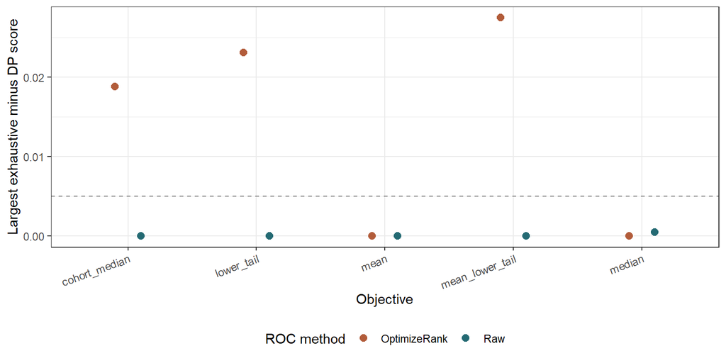

图中每个点是上表某一目标、某一 ROC 方法的最大搜索差距，虚线对应工程比较尺度。较高的点意味着至少有一个固定问题的近似搜索仍可改善；它不意味着该目标的预测性能更差。图示只比较搜索对各自目标的优化程度，不能把不同目标的得分单位混为同一个临床效应。

## 扩展目标增加了多少运行成本

默认 median 的直接计时：old 为冻结 0.8.5，new 为当前实现；时间为秒

| K | ROC | 旧DP(s) | 新DP(s) | 旧穷举(s) | 新穷举(s) | 新／旧DP | 穷举／DP |
| --- | --- | --- | --- | --- | --- | --- | --- |
| 4 | OptimizeRank | 0.28 | 0.28 | 8.65 | 8.56 | 1.0000 | 30.5357 |
| 5 | OptimizeRank | 0.29 | 0.30 | 13.18 | 12.97 | 1.0000 | 43.3000 |
| 6 | OptimizeRank | 0.31 | 0.31 | 17.11 | 17.05 | 1.0000 | 54.8387 |
| 4 | Raw | 0.15 | 0.17 | 6.01 | 6.05 | 1.1333 | 35.6471 |
| 5 | Raw | 0.12 | 0.12 | 7.42 | 7.35 | 1.0000 | 61.3333 |
| 6 | Raw | 0.12 | 0.13 | 8.38 | 8.36 | 1.0833 | 64.7692 |

同一输入、同一 R 进程中的配对测量显示，新／旧默认 DP 耗时比的分组中位数为 1.000–1.133。小于一表示本次测得更快，大于一表示存在额外成本。这是评分抽象的兼容成本，不能把既有 DP 相对穷举的收益全部归于这次目标扩展。当前默认穷举／DP 的加速比分组中位数为 30.54–64.77 倍。

计时每组重复 3 次，交替先后顺序，计时包含一次搜索的排序、初值、精修和结果整理，排除加载包与生成输入。穷举固定一个 worker，DP 固定一个主进程；两者的候选保留范围不同。样本较少时计时波动与进程启动成本占比可能较高，因此仅作本机描述性比较，不报告总体置信区间或 p 值。每次的候选数、评分次数、最优分数和映射均保留，可检查新旧运行是否完成了相同工作。

产品中的 `evaluations` 对应 `n_scored_proposals`，统计初值和精修提案的目标打分行数，重复提案会重复计数；它不包含并列判定中的均值重算及最终 ROC 复核，不能直接当作底层 AUC 函数的总调用次数。

## 较大规模能否运行

M=107/216，C=20，K=5/6/8/10/12；逐目标、逐 ROC 汇总

|  | 目标 | ROC | 运行数 | 最短(s) | 最长(s) | 区间模型(MiB) | 空队列×等级格数 |
| --- | --- | --- | --- | --- | --- | --- | --- |
| cohort_median.OptimizeRank | cohort_median | OptimizeRank | 10 | 6.41 | 31.63 | 15.471 | 2 |
| lower_tail.OptimizeRank | lower_tail | OptimizeRank | 10 | 7.83 | 27.99 | 15.471 | 0 |
| mean.OptimizeRank | mean | OptimizeRank | 10 | 6.39 | 29.54 | 15.471 | 0 |
| mean_lower_tail.OptimizeRank | mean_lower_tail | OptimizeRank | 10 | 7.89 | 31.12 | 15.471 | 0 |
| median.OptimizeRank | median | OptimizeRank | 10 | 7.22 | 30.83 | 15.471 | 1 |
| cohort_median.Raw | cohort_median | Raw | 10 | 4.97 | 16.66 | 15.471 | 2 |
| lower_tail.Raw | lower_tail | Raw | 10 | 4.98 | 18.63 | 15.471 | 12 |
| mean.Raw | mean | Raw | 10 | 4.16 | 13.24 | 15.471 | 0 |
| mean_lower_tail.Raw | mean_lower_tail | Raw | 10 | 5.14 | 18.34 | 15.471 | 6 |
| median.Raw | median | Raw | 10 | 5.09 | 17.94 | 15.471 | 0 |

结果显示，100 次实际搜索均产生了可复核候选，耗时范围为 4.16–31.63 秒。区间模型最大为 15.47 MiB；该数值仅指 R 对象大小，不是进程峰值内存。每一配置只测一次，不能据此估计运行时间的分布。

这些规模没有运行完整穷举，`partitions` 仅表示合法切分数量，不能换算成实测加速比。增加等级可能使部分队列缺少某些等级；表中保留其计数，未加入计划之外的最小人数约束。完整切点、AUC 向量与等级人数见 `objective-scaling.csv`，可供后续稳定性和校准检验使用。

## 测试与复现

本报告只读取正式基准 CSV，渲染时不重新搜索。独立手算测试验证分数定义、下尾分数权重和基本单调性；冻结回归核对旧默认与显式 `median` 的完整输出；目标集成和公开 API 测试覆盖两种搜索、参数透传、位置参数、NULL 分支和错误输入。验证说明列出实际命令、退出状态及包检查限制。

```powershell
& 'C:/R/R-4.3.1/bin/Rscript.exe' --vanilla test/normCCS-5-more/test-objectives.R
& 'C:/R/R-4.3.1/bin/Rscript.exe' --vanilla test/normCCS-5-more/scripts/tests/public-api.R
& 'C:/R/R-4.3.1/bin/Rscript.exe' --vanilla test/normCCS-5-more/benchmark-objectives.R
& 'C:/R/R-4.3.1/bin/Rscript.exe' --vanilla test/normCCS-5-more/diagnose-objective-gaps.R
& 'C:/R/R-4.3.1/bin/Rscript.exe' --vanilla test/normCCS-5-more/render-report.R --objectives
```

重复生成结果需显式传入 `--overwrite`。已有 simple 分析保留原目录和执行方式，未隐式补建 renv 或迁移为 targets。`objective-source-identity.csv`、配置快照和 session 文件记录当前计算来源；正式测试和报告使用同一入口，隔离测试位于 `tmp/tests/`。

全部输入由代码生成，真实患者全量验证为 **NOT_RUN**。本报告的差距、运行成本与映射变化均为确定性工程比较；它们不提供跨队列泛化改善、校准改善或临床获益的证据。